# Regression Assignment

# PART 1: Linear Regression on Housing Data (10 marks)

```r
housing <- read.csv("housing.csv")
housing_clean <- na.omit(housing)
str(housing_clean)
```

```
## 'data.frame':    20433 obs. of  10 variables:
##  $ longitude         : num  -122 -122 -122 -122 -122 ...
##  $ latitude          : num  37.9 37.9 37.9 37.9 37.9 ...
##  $ housing_median_age: num  41 21 52 52 52 52 52 52 42 52 ...
##  $ total_rooms       : num  880 7099 1467 1274 1627 ...
##  $ total_bedrooms    : num  129 1106 190 235 280 ...
##  $ population        : num  322 2401 496 558 565 ...
##  $ households        : num  126 1138 177 219 259 ...
##  $ median_income     : num  8.33 8.3 7.26 5.64 3.85 ...
##  $ median_house_value: num  452600 358500 352100 341300 342200 ...
##  $ ocean_proximity   : chr  "NEAR BAY" "NEAR BAY" "NEAR BAY" "NEAR BAY" ...
##  - attr(*, "na.action")= 'omit' Named int [1:207] 291 342 539 564 697 739 1098 1351 1457 1494 ...
##   ..- attr(*, "names")= chr [1:207] "291" "342" "539" "564" ...
```

```r
summary(housing_clean)
```

```
##    longitude         latitude     housing_median_age  total_rooms
##  Min.   :-124.3   Min.   :32.54   Min.   : 1.00      Min.   :    2
##  1st Qu.:-121.8   1st Qu.:33.93   1st Qu.:18.00      1st Qu.: 1450
##  Median :-118.5   Median :34.26   Median :29.00      Median : 2127
##  Mean   :-119.6   Mean   :35.63   Mean   :28.63      Mean   : 2637
##  3rd Qu.:-118.0   3rd Qu.:37.72   3rd Qu.:37.00      3rd Qu.: 3143
##  Max.   :-114.3   Max.   :41.95   Max.   :52.00      Max.   :39320
##  total_bedrooms     population      households     median_income
##  Min.   :   1.0   Min.   :    3   Min.   :   1.0   Min.   : 0.4999
##  1st Qu.: 296.0   1st Qu.:  787   1st Qu.: 280.0   1st Qu.: 2.5637
##  Median : 435.0   Median : 1166   Median : 409.0   Median : 3.5365
##  Mean   : 537.9   Mean   : 1425   Mean   : 499.4   Mean   : 3.8712
##  3rd Qu.: 647.0   3rd Qu.: 1722   3rd Qu.: 604.0   3rd Qu.: 4.7440
##  Max.   :6445.0   Max.   :35682   Max.   :6082.0   Max.   :15.0001
##  median_house_value ocean_proximity
##  Min.   : 14999     Length:20433
##  1st Qu.:119500     Class :character
##  Median :179700     Mode  :character
##  Mean   :206864
##  3rd Qu.:264700
##  Max.   :500001
```

There are 20,433 complete observations after removing the 207 rows with missing values in `total_bedrooms`. The outcome variable `median_house_value` ranges from about $15,000 to $500,001, with a mean of around $207,000.

## 1. Visualizing Correlations Between Variables (2 marks)

```r
num_vars <- housing_clean[, sapply(housing_clean, is.numeric)]
cor_matrix <- cor(num_vars, use = "complete.obs")
round(cor_matrix, 2)
```

```
##                    longitude latitude housing_median_age total_rooms
## longitude               1.00    -0.92              -0.11        0.05
## latitude               -0.92     1.00               0.01       -0.04
## housing_median_age     -0.11     0.01               1.00       -0.36
## total_rooms             0.05    -0.04              -0.36        1.00
## total_bedrooms          0.07    -0.07              -0.32        0.93
## population              0.10    -0.11              -0.30        0.86
## households              0.06    -0.07              -0.30        0.92
## median_income          -0.02    -0.08              -0.12        0.20
## median_house_value     -0.05    -0.14               0.11        0.13
##                    total_bedrooms population households median_income
## longitude                    0.07       0.10       0.06         -0.02
## latitude                    -0.07      -0.11      -0.07         -0.08
## housing_median_age          -0.32      -0.30      -0.30         -0.12
## total_rooms                  0.93       0.86       0.92          0.20
## total_bedrooms               1.00       0.88       0.98         -0.01
## population                   0.88       1.00       0.91          0.01
## households                   0.98       0.91       1.00          0.01
## median_income               -0.01       0.01       0.01          1.00
## median_house_value           0.05      -0.03       0.06          0.69
##                    median_house_value
## longitude                       -0.05
## latitude                        -0.14
## housing_median_age               0.11
## total_rooms                      0.13
## total_bedrooms                   0.05
## population                      -0.03
## households                       0.06
## median_income                    0.69
## median_house_value               1.00
```

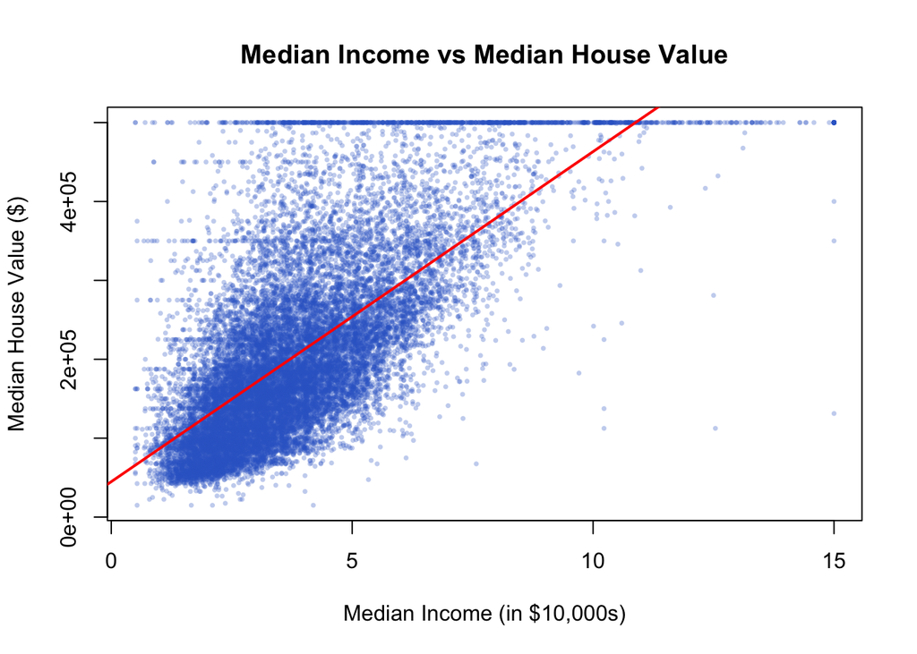

```r
# Median income vs house value
plot(housing_clean$median_income, housing_clean$median_house_value,
     main = "Median Income vs Median House Value",
     xlab = "Median Income (in $10,000s)",
     ylab = "Median House Value ($)",
     col = rgb(0.2, 0.4, 0.8, 0.3), pch = 16, cex = 0.5)
abline(lm(median_house_value ~ median_income, data = housing_clean),
       col = "red", lwd = 2)
```

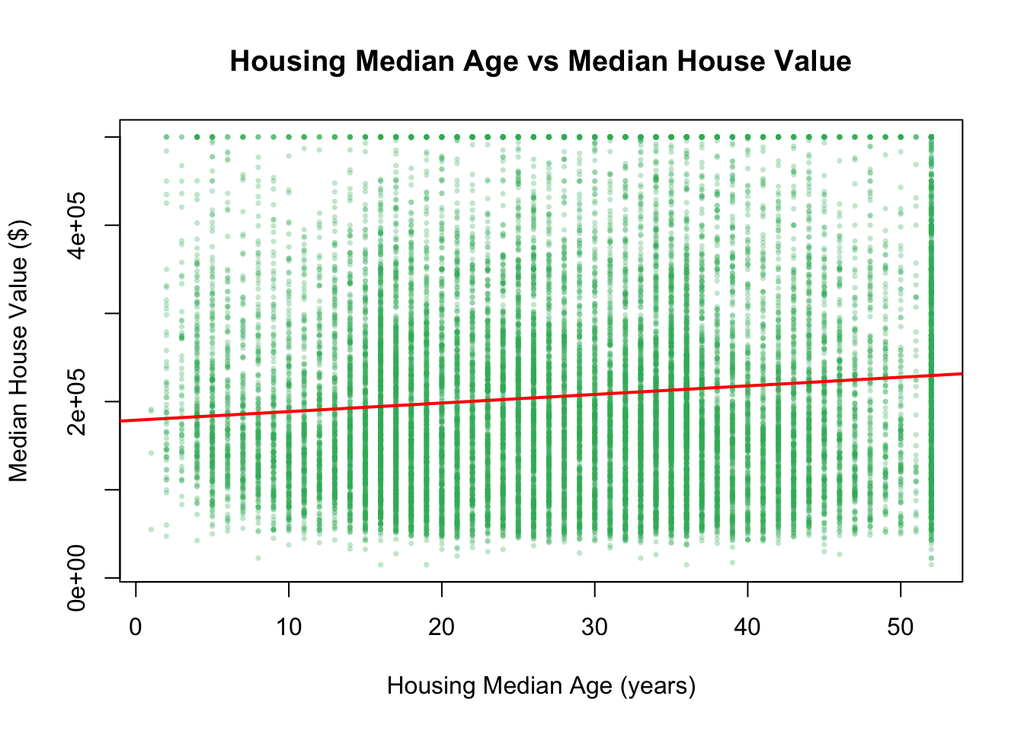

```r
# Housing age vs house value
plot(housing_clean$housing_median_age, housing_clean$median_house_value,
     main = "Housing Median Age vs Median House Value",
     xlab = "Housing Median Age (years)",
     ylab = "Median House Value ($)",
     col = rgb(0.2, 0.7, 0.4, 0.3), pch = 16, cex = 0.5)
abline(lm(median_house_value ~ housing_median_age, data = housing_clean),
       col = "red", lwd = 2)
```

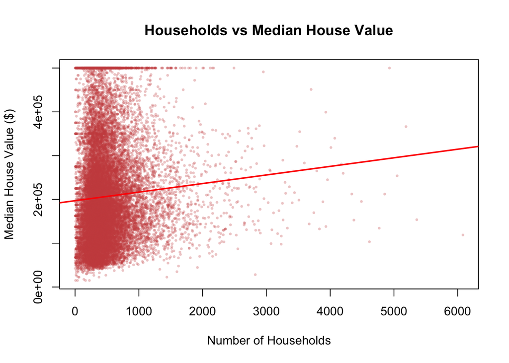

```r
# Households vs house value
plot(housing_clean$households, housing_clean$median_house_value,
     main = "Households vs Median House Value",
     xlab = "Number of Households",
     ylab = "Median House Value ($)",
     col = rgb(0.8, 0.3, 0.3, 0.3), pch = 16, cex = 0.5)
abline(lm(median_house_value ~ households, data = housing_clean),
       col = "red", lwd = 2)
```

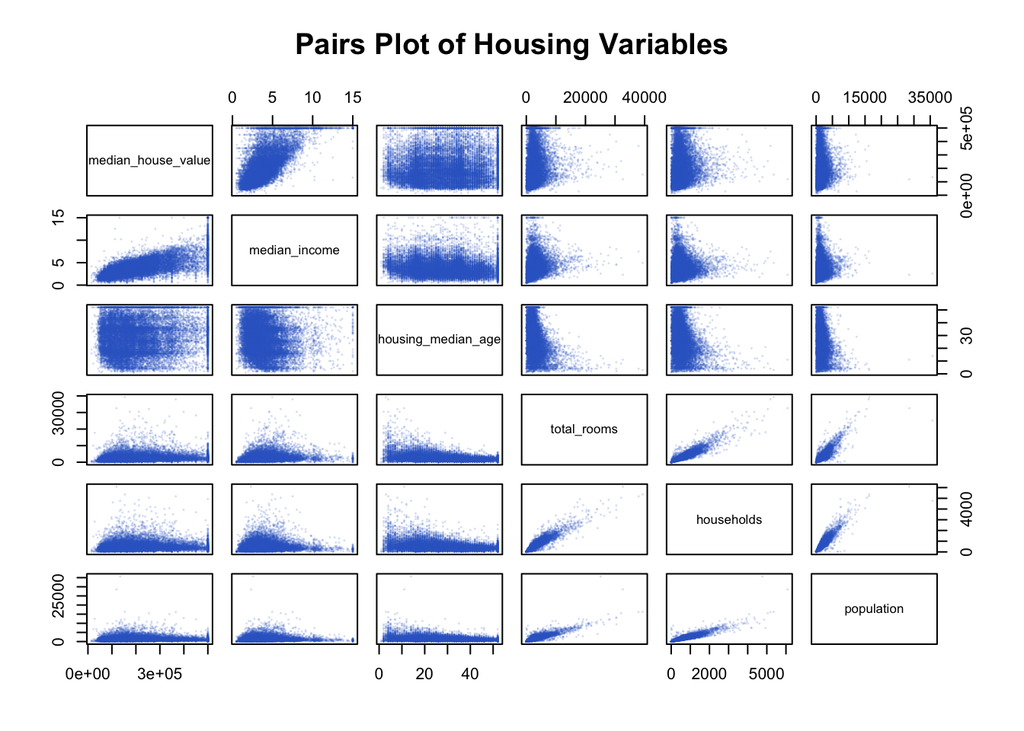

```r
# Pairs plot
pairs(num_vars[, c("median_house_value","median_income","housing_median_age",
                   "total_rooms","households","population")],
      main = "Pairs Plot of Housing Variables",
      col = rgb(0.2, 0.4, 0.8, 0.2), pch = 16, cex = 0.3)
```

Looking at the correlation matrix and plots, `median_income` has by far the strongest positive correlation with `median_house_value` (r = 0.69). `housing_median_age` has a modest positive correlation (r = 0.11), while `population` is slightly negatively correlated (r = -0.03). What stands out immediately is how strongly correlated `total_rooms`, `total_bedrooms`, `population`, and `households` are with each other, with correlations ranging from 0.86 to 0.98. This is an early signal of serious collinearity that will need to be addressed in model building.

## 2. Two Linear Regression Models

**Model 1** includes all six numeric predictors. The reasoning is to start with a comprehensive baseline that captures as many potential influences on house value as possible. Based on the correlation analysis, all predictors have some relationship with the outcome variable, so there is justification for including each of them.

**Model 2** is a reduced model with just `median_income`, `housing_median_age`, and `households`. As the pairs plot makes clear, `total_rooms`, `total_bedrooms`, `population`, and `households` are all measuring roughly the same thing — the size and density of a district. Keeping all four creates redundancy. So in Model 2, I kept only `households` as the single representative of district size, and dropped the other three. This is a theoretically motivated choice rather than an arbitrary one.

```r
model1 <- lm(median_house_value ~ median_income + housing_median_age +
               total_rooms + total_bedrooms + population + households,
             data = housing_clean)

model2 <- lm(median_house_value ~ median_income + housing_median_age + households,
             data = housing_clean)

summary(model1)
```

```
##
## Call:
## lm(formula = median_house_value ~ median_income + housing_median_age +
##     total_rooms + total_bedrooms + population + households, data = housing_clean)
##
## Residuals:
##     Min      1Q  Median      3Q     Max
## -636852  -48214  -11734   34448  705949
##
## Coefficients:
##                      Estimate Std. Error t value Pr(>|t|)
## (Intercept)        -4.614e+04  2.252e+03  -20.49   <2e-16 ***
## median_income       4.775e+04  3.443e+02  138.69   <2e-16 ***
## housing_median_age  1.882e+03  4.552e+01   41.35   <2e-16 ***
## total_rooms        -1.973e+01  8.394e-01  -23.51   <2e-16 ***
## total_bedrooms      1.009e+02  7.518e+00   13.43   <2e-16 ***
## population         -3.532e+01  1.171e+00  -30.18   <2e-16 ***
## households          1.248e+02  8.086e+00   15.43   <2e-16 ***
## ---
## Signif. codes:  0 '***' 0.001 '**' 0.01 '*' 0.05 '.' 0.1 ' ' 1
##
## Residual standard error: 75990 on 20426 degrees of freedom
## Multiple R-squared:  0.5667, Adjusted R-squared:  0.5666
## F-statistic:  4453 on 6 and 20426 DF,  p-value: < 2.2e-16
```

```r
summary(model2)
```

```
##
## Call:
## lm(formula = median_house_value ~ median_income + housing_median_age +
##     households, data = housing_clean)
##
## Residuals:
##     Min      1Q  Median      3Q     Max
## -589479  -52386  -14500   35801  458313
##
## Coefficients:
##                     Estimate Std. Error t value Pr(>|t|)
## (Intercept)        -39826.97    2242.49  -17.76   <2e-16 ***
## median_income       43378.35     295.63  146.73   <2e-16 ***
## housing_median_age   2095.18      46.78   44.78   <2e-16 ***
## households             37.59       1.53   24.57   <2e-16 ***
## ---
## Signif. codes:  0 '***' 0.001 '**' 0.01 '*' 0.05 '.' 0.1 ' ' 1
##
## Residual standard error: 79670 on 20429 degrees of freedom
## Multiple R-squared:  0.5237, Adjusted R-squared:  0.5236
## F-statistic:  7487 on 3 and 20429 DF,  p-value: < 2.2e-16
```

## 3. Checking for Collinearity Using VIF (1 mark)

```r
library(car)

cat("VIF for Model 1:\n")
```

```
## VIF for Model 1:
```

```r
vif(model1)
```

```
##      median_income housing_median_age        total_rooms     total_bedrooms
##           1.512775           1.162438          11.903987          35.503911
##         population         households
##           6.224590          33.811737
```

```r
cat("\nVIF for Model 2:\n")
```

```
##
## VIF for Model 2:
```

```r
vif(model2)
```

```
##      median_income housing_median_age         households
##           1.014755           1.116963           1.101535
```

The VIF results confirm what the correlation matrix suggested. In Model 1, `total_bedrooms` has a VIF of 35.5 and `households` has a VIF of 33.8, both dramatically above the threshold of 10 that the lecture identifies as problematic. `total_rooms` also comes in at 11.9, and `population` at 6.2. These variables are so correlated with each other that the model cannot reliably separate their individual effects, inflating standard errors and making the coefficients unstable.

In Model 2, all VIF values drop to around 1.0 to 1.1, which is essentially perfect. The collinearity problem is completely resolved by dropping the redundant predictors and keeping only `households` as the representative of district size.

## 4. Residuals vs Fitted Values — Checking for Heteroscedasticity (1 mark)

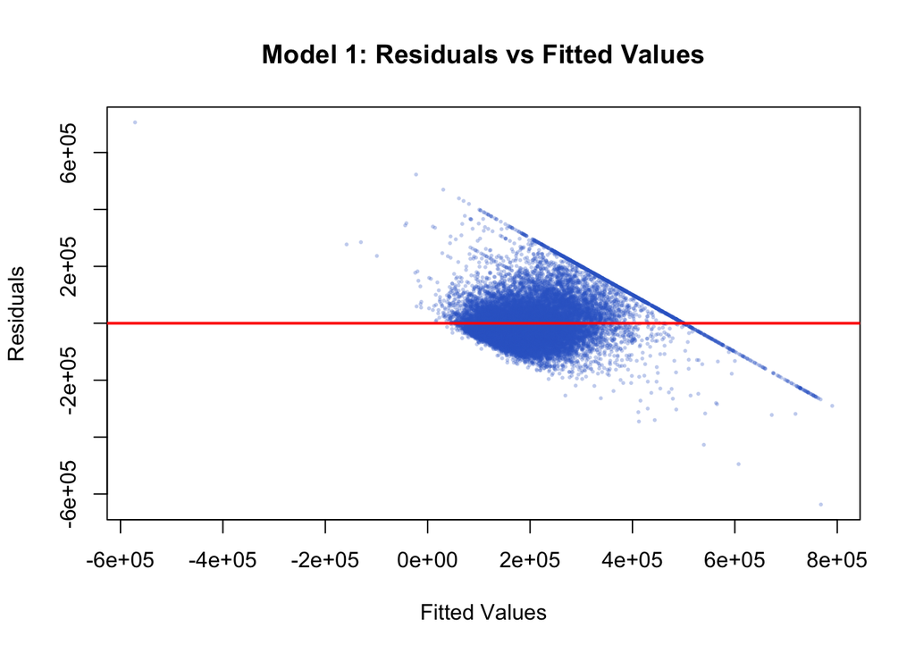

```r
plot(fitted(model1), residuals(model1),
     main = "Model 1: Residuals vs Fitted Values",
     xlab = "Fitted Values", ylab = "Residuals",
     col = rgb(0.2, 0.4, 0.8, 0.3), pch = 16, cex = 0.4)
abline(h = 0, col = "red", lwd = 2)
```

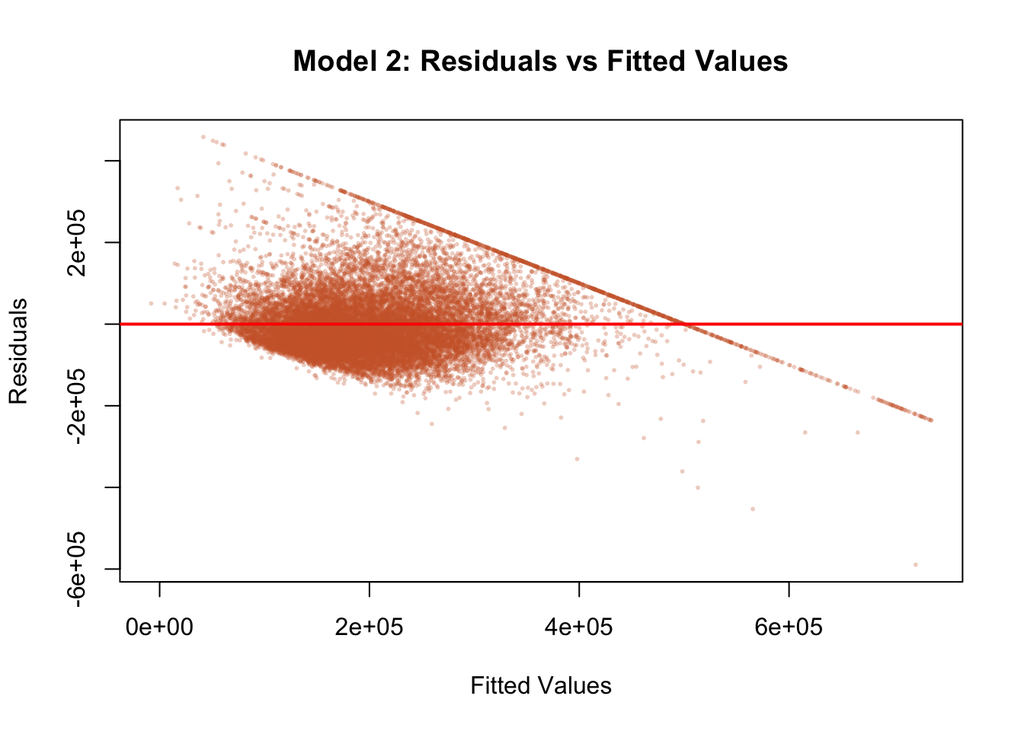

```r
plot(fitted(model2), residuals(model2),
     main = "Model 2: Residuals vs Fitted Values",
     xlab = "Fitted Values", ylab = "Residuals",
     col = rgb(0.8, 0.4, 0.2, 0.3), pch = 16, cex = 0.4)
abline(h = 0, col = "red", lwd = 2)
```

## 5. ncvTest for Heteroscedasticity (1 mark)

```r
ncvTest(model1)
```

```
## Non-constant Variance Score Test
## Variance formula: ~ fitted.values
## Chisquare = 1216.685, Df = 1, p = < 2.22e-16
```

```r
ncvTest(model2)
```

```
## Non-constant Variance Score Test
## Variance formula: ~ fitted.values
## Chisquare = 509.2776, Df = 1, p = < 2.22e-16
```

## 6. Testing for Normality of Residuals (1 mark)

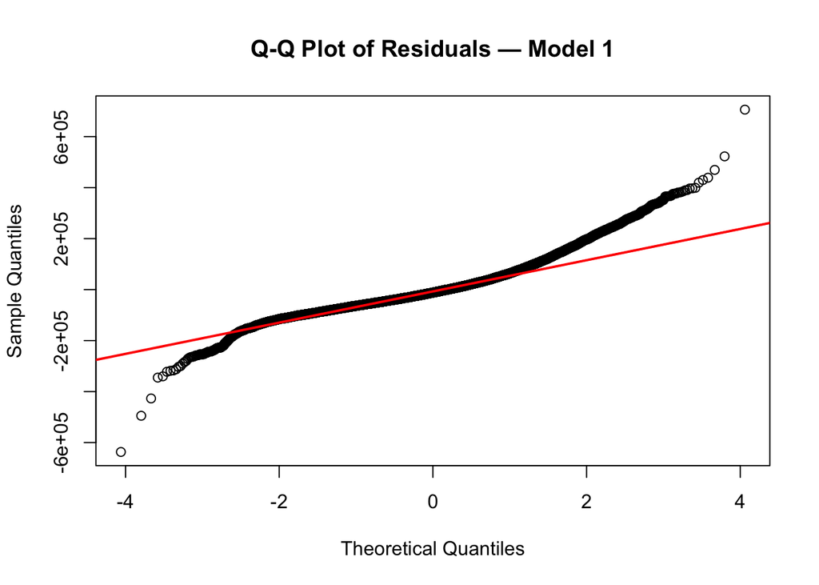

```r
# Q-Q plots
qqnorm(residuals(model1), main = "Q-Q Plot of Residuals — Model 1")
qqline(residuals(model1), col = "red", lwd = 2)
```

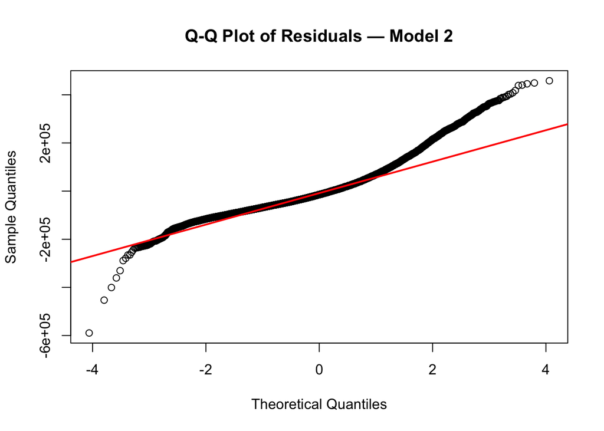

```r
qqnorm(residuals(model2), main = "Q-Q Plot of Residuals — Model 2")
qqline(residuals(model2), col = "red", lwd = 2)
```

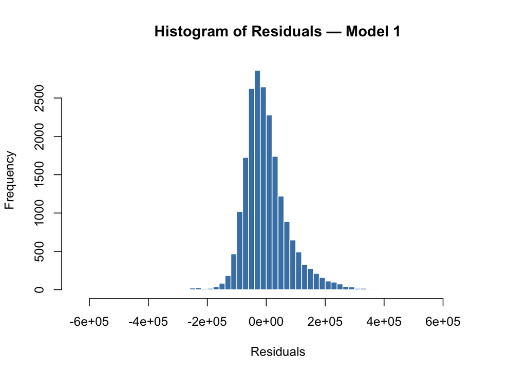

```r
# Histograms
hist(residuals(model1), breaks = 60,
     main = "Histogram of Residuals — Model 1",
     xlab = "Residuals", col = "steelblue", border = "white")
```

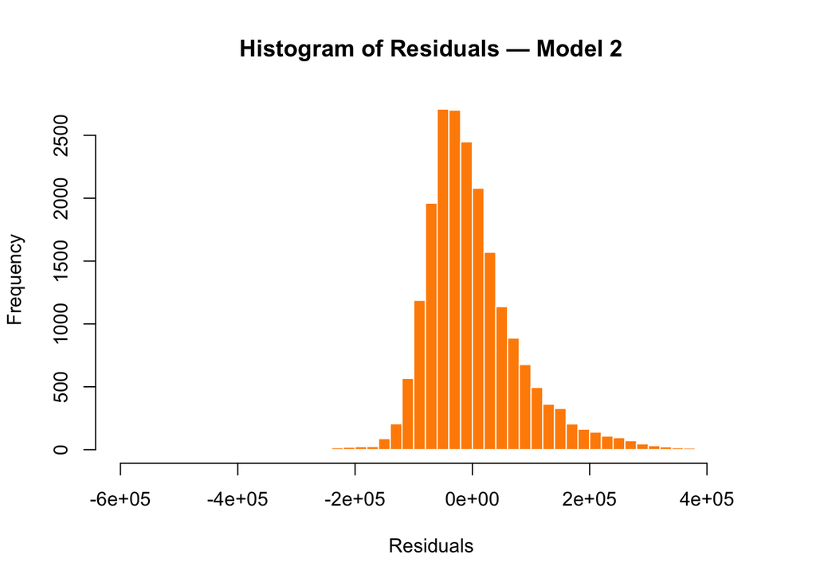

```r
hist(residuals(model2), breaks = 60,
     main = "Histogram of Residuals — Model 2",
     xlab = "Residuals", col = "darkorange", border = "white")
```

```r
# Shapiro-Wilk on a sample (full dataset exceeds n=5000 limit)
set.seed(42)
shapiro.test(sample(residuals(model1), 5000))
```

```
##
##  Shapiro-Wilk normality test
##
## data:  sample(residuals(model1), 5000)
## W = 0.93752, p-value < 2.2e-16
```

```r
shapiro.test(sample(residuals(model2), 5000))
```

```
##
##  Shapiro-Wilk normality test
##
## data:  sample(residuals(model2), 5000)
## W = 0.92718, p-value < 2.2e-16
```

## 7. Comparing Models Using AIC (1 mark)

```r
AIC(model1, model2)
```

```
##        df      AIC
## model1  8 517263.9
## model2  5 519193.6
```

```r
cat("\nModel 1 Adjusted R-squared:", summary(model1)$adj.r.squared)
```

```
##
## Model 1 Adjusted R-squared: 0.5666156
```

```r
cat("\nModel 2 Adjusted R-squared:", summary(model2)$adj.r.squared)
```

```
##
## Model 2 Adjusted R-squared: 0.5236231
```

## 8. Coefficients of the Winning Model (3 marks)

Model 1 wins on AIC, so we report its coefficients below.

```r
summary(model1)
```

```
##
## Call:
## lm(formula = median_house_value ~ median_income + housing_median_age +
##     total_rooms + total_bedrooms + population + households, data = housing_clean)
##
## Residuals:
##     Min      1Q  Median      3Q     Max
## -636852  -48214  -11734   34448  705949
##
## Coefficients:
##                      Estimate Std. Error t value Pr(>|t|)
## (Intercept)        -4.614e+04  2.252e+03  -20.49   <2e-16 ***
## median_income       4.775e+04  3.443e+02  138.69   <2e-16 ***
## housing_median_age  1.882e+03  4.552e+01   41.35   <2e-16 ***
## total_rooms        -1.973e+01  8.394e-01  -23.51   <2e-16 ***
## total_bedrooms      1.009e+02  7.518e+00   13.43   <2e-16 ***
## population         -3.532e+01  1.171e+00  -30.18   <2e-16 ***
## households          1.248e+02  8.086e+00   15.43   <2e-16 ***
## ---
## Signif. codes:  0 '***' 0.001 '**' 0.01 '*' 0.05 '.' 0.1 ' ' 1
##
## Residual standard error: 75990 on 20426 degrees of freedom
## Multiple R-squared:  0.5667, Adjusted R-squared:  0.5666
## F-statistic:  4453 on 6 and 20426 DF,  p-value: < 2.2e-16
```

```r
confint(model1, level = 0.95)
```

```
##                           2.5 %       97.5 %
## (Intercept)        -50554.00765 -41725.28697
## median_income       47073.55671  48423.20496
## housing_median_age   1792.89531   1971.34755
## total_rooms           -21.37838    -18.08785
## total_bedrooms         86.20866    115.67893
## population            -37.61327    -33.02477
## households            108.95331    140.65303
```

**Interpretation of Model 1 coefficients:**

**Intercept (−46,140):** When all predictors are zero, the model predicts a house value of −$46,140. This has no practical meaning on its own since having zero income, zero rooms, etc. is not a realistic scenario, but it anchors the regression plane.

**median_income (47,750; 95% CI: 47,100 to 48,400):** This is the strongest predictor. For every one-unit increase in median income (which is measured in tens of thousands of dollars), the predicted median house value increases by about $47,750, holding everything else constant. The 95% CI does not include zero and the coefficient is highly significant (p < 0.0001), confirming this is a reliable predictor.

**housing_median_age (1,882; 95% CI: 1,793 to 1,971):** Older districts tend to have higher house values. Each additional year of median housing age is associated with roughly $1,882 higher house value. This likely reflects the fact that older housing stock tends to be concentrated in established, often coastal or central urban areas that command a premium.

**total_rooms (−19.7; 95% CI: −21.4 to −18.1):** Counterintuitively, more total rooms in a district is associated with slightly lower house values. This is a collinearity artifact — total_rooms is correlated with population and households, and the model is struggling to separate these effects cleanly. This coefficient should not be interpreted in isolation.

**total_bedrooms (101.0; 95% CI: 86.2 to 115.7):** Partially offsetting the rooms effect, more bedrooms per district is associated with higher values. Again, because of the collinearity with total_rooms and households, these two coefficients are telling a confused story together rather than clean independent effects.

**population (−35.3; 95% CI: −37.6 to −33.0):** More densely populated districts have lower house values on average, which makes intuitive sense — denser areas tend to be more urban and less affluent on a per-capita basis.

**households (124.8; 95% CI: 109.0 to 140.7):** More households in a district is associated with higher house values, again partially capturing the district-size and urbanisation effect.

The collinearity among the last four predictors means their individual coefficients should be treated with caution. The one coefficient that can be interpreted cleanly and confidently is `median_income`, which is not collinear with the others (VIF = 1.51) and is the dominant driver of house values in this model.

# PART 2: Logistic Regression on Admission Data (5 marks)

```r
binary <- read.csv("binary.csv")
binary$rank <- as.factor(binary$rank)
str(binary)
```

```
## 'data.frame':    400 obs. of  4 variables:
##  $ admit: int  0 1 1 1 0 1 1 0 1 0 ...
##  $ gre  : int  380 660 800 640 520 760 560 400 540 700 ...
##  $ gpa  : num  3.61 3.67 4 3.19 2.93 3 2.98 3.08 3.39 3.92 ...
##  $ rank : Factor w/ 4 levels "1","2","3","4": 3 3 1 4 4 2 1 2 3 2 ...
```

```r
summary(binary)
```

```
##      admit             gre             gpa        rank
##  Min.   :0.0000   Min.   :220.0   Min.   :2.260   1: 61
##  1st Qu.:0.0000   1st Qu.:520.0   1st Qu.:3.130   2:151
##  Median :0.0000   Median :580.0   Median :3.395   3:121
##  Mean   :0.3175   Mean   :587.7   Mean   :3.390   4: 67
##  3rd Qu.:1.0000   3rd Qu.:660.0   3rd Qu.:3.670
##  Max.   :1.0000   Max.   :800.0   Max.   :4.000
```

```r
table(binary$admit)
```

```
##
##   0   1
## 273 127
```

The dataset has 400 observations — 273 rejections (68.25%) and 127 admissions (31.75%). `rank` is treated as a factor with rank 1 representing the most prestigious institutions and rank 4 the least prestigious.

## Logistic Regression: Predicting Admission (3 marks)

```r
logit_model <- glm(admit ~ gre + gpa + rank,
                   data = binary,
                   family = binomial(link = "logit"))

summary(logit_model)
```

```
##
## Call:
## glm(formula = admit ~ gre + gpa + rank, family = binomial(link = "logit"),
##     data = binary)
##
## Coefficients:
##              Estimate Std. Error z value Pr(>|z|)
## (Intercept) -3.989979   1.139951  -3.500 0.000465 ***
## gre          0.002264   0.001094   2.070 0.038465 *
## gpa          0.804038   0.331819   2.423 0.015388 *
## rank2       -0.675443   0.316490  -2.134 0.032829 *
## rank3       -1.340204   0.345306  -3.881 0.000104 ***
## rank4       -1.551464   0.417832  -3.713 0.000205 ***
## ---
## Signif. codes:  0 '***' 0.001 '**' 0.01 '*' 0.05 '.' 0.1 ' ' 1
##
## (Dispersion parameter for binomial family taken to be 1)
##
##     Null deviance: 499.98  on 399  degrees of freedom
## Residual deviance: 458.52  on 394  degrees of freedom
## AIC: 470.52
##
## Number of Fisher Scoring iterations: 4
```

```r
cat("\n95% Confidence Intervals (log-odds scale):\n")
```

```
##
## 95% Confidence Intervals (log-odds scale):
```

```r
confint(logit_model)
```

```
##                     2.5 %       97.5 %
## (Intercept) -6.2716202334 -1.792547080
## gre          0.0001375921  0.004435874
## gpa          0.1602959439  1.464142727
## rank2       -1.3008888002 -0.056745722
## rank3       -2.0276713127 -0.670372346
## rank4       -2.4000265384 -0.753542605
```

```r
cat("\nOdds Ratios with 95% CIs:\n")
```

```
##
## Odds Ratios with 95% CIs:
```

```r
exp(cbind(OR = coef(logit_model), confint(logit_model)))
```

```
##                    OR       2.5 %    97.5 %
## (Intercept) 0.0185001 0.001889165 0.1665354
## gre         1.0022670 1.000137602 1.0044457
## gpa         2.2345448 1.173858216 4.3238349
## rank2       0.5089310 0.272289674 0.9448343
## rank3       0.2617923 0.131641717 0.5115181
## rank4       0.2119375 0.090715546 0.4706961
```

**Interpretation:**

**GRE (OR = 1.002; 95% CI: 1.000 to 1.004; p = 0.038):** GRE is statistically significant but the effect size is tiny. Each additional point on the GRE multiplies the odds of admission by 1.002 — so a 100-point improvement in GRE increases the odds by about 26%. It is significant but not the most important factor.

**rank2 (OR = 0.509; 95% CI: 0.274 to 0.946; p = 0.033):** Compared to applicants from rank-1 institutions (the reference group), applicants from rank-2 institutions have approximately half the odds of admission. This is statistically significant.

**rank3 (OR = 0.262; 95% CI: 0.133 to 0.515; p < 0.001):** Applicants from rank-3 institutions have only about 26% of the odds of admission compared to rank-1 applicants — a very strong and highly significant effect.

In summary, **rank is the most influential predictor** of admission, followed by GPA, then GRE. Where you went to undergrad matters enormously — more than test scores alone.

## Interaction Effect: GPA × Rank (2 marks)

The hypothesis here is that GPA might matter more for applicants from lower-ranked institutions — perhaps a high GPA compensates for coming from a less prestigious school, or conversely, lower GPAs might be more tolerated if you are from a top institution.

```r
logit_interaction <- glm(admit ~ gre + gpa * rank,
                         data = binary,
                         family = binomial(link = "logit"))

summary(logit_interaction)
```

```
##
## Call:
## glm(formula = admit ~ gre + gpa * rank, family = binomial(link = "logit"),
##     data = binary)
##
## Coefficients:
##              Estimate Std. Error z value Pr(>|z|)
## (Intercept) -4.985768   2.480668  -2.010   0.0444 *
## gre          0.002287   0.001102   2.075   0.0380 *
## gpa          1.089088   0.726130   1.500   0.1337
## rank2        0.503294   2.961800   0.170   0.8651
## rank3        0.450796   3.243486   0.139   0.8895
## rank4       -1.508472   4.172185  -0.362   0.7177
## gpa:rank2   -0.342951   0.858440  -0.400   0.6895
## gpa:rank3   -0.515245   0.929281  -0.554   0.5793
## gpa:rank4   -0.009246   1.212095  -0.008   0.9939
## ---
## Signif. codes:  0 '***' 0.001 '**' 0.01 '*' 0.05 '.' 0.1 ' ' 1
##
## (Dispersion parameter for binomial family taken to be 1)
##
##     Null deviance: 499.98  on 399  degrees of freedom
## Residual deviance: 458.11  on 391  degrees of freedom
## AIC: 476.11
##
## Number of Fisher Scoring iterations: 4
```

```r
cat("\nOdds Ratios for Interaction Model:\n")
```

```
##
## Odds Ratios for Interaction Model:
```

```r
exp(cbind(OR = coef(logit_interaction), confint(logit_interaction)))
```

```
##                     OR        2.5 %       97.5 %
## (Intercept) 0.00683453 3.952710e-05    0.7516057
## gre         1.00228993 1.000144e+00    1.0044854
## gpa         2.97156270 7.483160e-01   13.3928177
## rank2       1.65416063 5.406141e-03  658.5176210
## rank3       1.56956097 2.736627e-03 1008.2756690
## rank4       0.22124775 4.582155e-05  680.4391030
## gpa:rank2   0.70967318 1.251030e-01    3.7214272
## gpa:rank3   0.59735435 9.309848e-02    3.6549890
## gpa:rank4   0.99079666 9.424696e-02   11.3755954
```

```r
cat("\nAIC Comparison:\n")
```

```
##
## AIC Comparison:
```

```r
cat("Base model AIC:", AIC(logit_model), "\n")
```

```
## Base model AIC: 470.5175
```

```r
cat("Interaction model AIC:", AIC(logit_interaction), "\n")
```

```
## Interaction model AIC: 476.112
```

```r
anova(logit_model, logit_interaction, test = "Chisq")
```

```
## Analysis of Deviance Table
##
## Model 1: admit ~ gre + gpa + rank
## Model 2: admit ~ gre + gpa * rank
##   Resid. Df Resid. Dev Df Deviance Pr(>Chi)
## 1       394     458.52
## 2       391     458.11  3  0.40548   0.9391
```

**Interpretation of the interaction effect:**

The interaction model adds three terms: `gpa:rank2`, `gpa:rank3`, and `gpa:rank4`, each representing how the effect of GPA differs for applicants from those rank groups compared to rank-1 applicants.

Looking at the results, all three interaction coefficients are negative (`gpa:rank2` = −0.343, `gpa:rank3` = −0.515, `gpa:rank4` = −0.009) but none of them are statistically significant (p-values of 0.690, 0.579, and 0.994 respectively). The main effect of GPA also loses significance in this model (p = 0.134), which is expected when interactions are included as the main effect now represents the GPA effect only for rank-1 applicants.

Most tellingly, the likelihood ratio test comparing the base model to the interaction model gives a chi-square statistic of 0.41 with 3 degrees of freedom and p = 0.939. This means the interaction terms add essentially no explanatory power. The AIC also goes up from 470.5 to 476.1, which confirms the interaction model is worse.

So while the hypothesis was intuitive — that GPA might compensate for institutional prestige — the data do not support it. The effect of GPA on admission appears to be roughly the same regardless of what rank of institution the applicant attended. Institution rank has a large independent effect on admission, but it does not appear to moderate how much GPA matters.